# Data Cleaning

In this project we use [Titanic Data Set from Kaggle](https://www.kaggle.com/c/titanic), to see how to clean data. Our prediction target is a classification problem: 'suvival or deceased'. This memo is just for data cleaning, we will use a logistic model later for the classification.

```python
import pandas as pd
import numpy as np
import matplotlib.pyplot as plt
import seaborn as sns
%matplotlib inline
```

```python
train = pd.read_csv('titanic_train.csv')
train.head()
```

|  | PassengerId | Survived | Pclass | Name | Sex | Age | SibSp | Parch | Ticket | Fare | Cabin | Embarked |
| --- | --- | --- | --- | --- | --- | --- | --- | --- | --- | --- | --- | --- |
| 0 | 1 | 0 | 3 | Braund, Mr. Owen Harris | male | 22.0 | 1 | 0 | A/5 21171 | 7.2500 | NaN | S |
| 1 | 2 | 1 | 1 | Cumings, Mrs. John Bradley (Florence Briggs Th... | female | 38.0 | 1 | 0 | PC 17599 | 71.2833 | C85 | C |
| 2 | 3 | 1 | 3 | Heikkinen, Miss. Laina | female | 26.0 | 0 | 0 | STON/O2. 3101282 | 7.9250 | NaN | S |
| 3 | 4 | 1 | 1 | Futrelle, Mrs. Jacques Heath (Lily May Peel) | female | 35.0 | 1 | 0 | 113803 | 53.1000 | C123 | S |
| 4 | 5 | 0 | 3 | Allen, Mr. William Henry | male | 35.0 | 0 | 0 | 373450 | 8.0500 | NaN | S |

## Missing Data

Use **Seabon's heatmap** to check missing data quickly

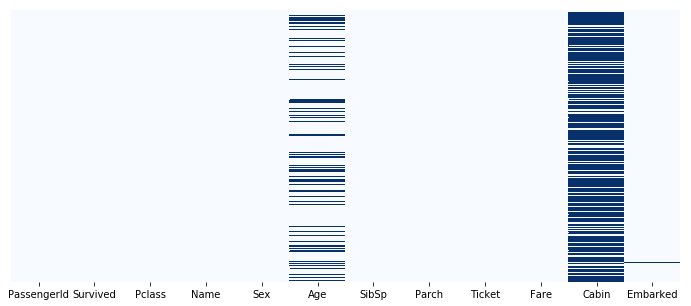

```python
plt.figure(figsize=(12, 5))
sns.heatmap(train.isnull(),yticklabels=False,cbar=False,cmap='Blues')
# yticklabels : tick in the left side
# cbar: color bar, which is none in this case
# cmap: color of the map. error message gives a list of cmap values.
```

### Count Number of Missing data

```python
## count number of missing rows:
_sum = sum(train['Age'].isnull().tolist())
loss_rate = _sum / len(train['Age'])
print(loss_rate)
```

```
0.19865319865319866
```

For 'Age' column, 20% of data is missing = small lossing rate for **reasonable replacement** with some form of imputation. For 'Cabin' column, we missed too much data = probably **drop** this later, or **change it to another feature like "Cabin Known: 1 or 0"**

## Fill in the Age Data

To fill in data, we need to know the relationship of 'age' with other features. So we need to check data and find what is 'age' related to.

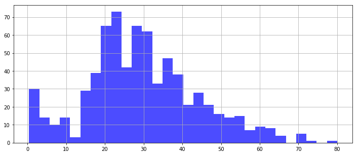

```python
plt.figure(figsize=(12, 5))
train['Age'].hist(bins=30,color='blue',alpha=0.7)
```

Maybe age effects the PClass (becasue older people has more money?), so we have:

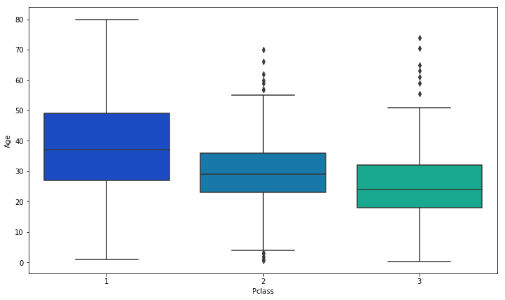

```python
plt.figure(figsize=(12, 7))
sns.boxplot(x='Pclass',y='Age',data=train,palette='winter')
```

Therefore, we can use the **average age** for each 'Pclass' to fill in the missing 'age' data:

```python
def fillin_age(col):
    dict_pclass_age = {1:37, 2:30, 3:25}
    age    = col[0]
    pclass = col[1]
    if pd.isnull(age):
        return dict_pclass_age[pclass]
    else:
        return age
```

```python
train['Age'] = train[['Age','Pclass']].apply(fillin_age,axis=1)
```

By the fillin_age function, we can fillin the age data. Let us check the fillin result by the heatmap:

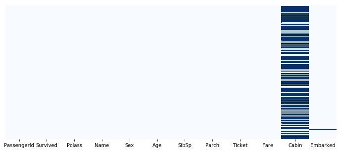

```python
plt.figure(figsize=(12, 5))
sns.heatmap(train.isnull(),yticklabels=False,cbar=False,cmap='Blues')
```

The benefit of the average age method, is our trend between Pclass and age doesn't changed:

[figure not shown]

```python
plt.figure(figsize=(12, 7))
sns.boxplot(x='Pclass',y='Age',data=train,palette='winter')
```

And the price of fillin, is that we have different age distribution in our data set. (compare to the original age distribution which would not be real too because of the NaN rows)

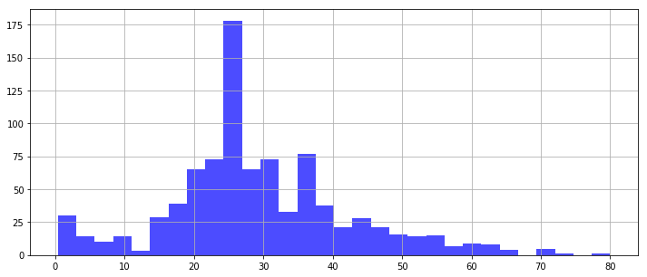

```python
plt.figure(figsize=(12, 5))
train['Age'].hist(bins=30,color='blue',alpha=0.7)
```

## Drop the Cabin Column

```python
train.drop('Cabin',axis=1,inplace=True)
train.head()
```

|  | PassengerId | Survived | Pclass | Name | Sex | Age | SibSp | Parch | Ticket | Fare | Embarked |
| --- | --- | --- | --- | --- | --- | --- | --- | --- | --- | --- | --- |
| 0 | 1 | 0 | 3 | Braund, Mr. Owen Harris | male | 22.0 | 1 | 0 | A/5 21171 | 7.2500 | S |
| 1 | 2 | 1 | 1 | Cumings, Mrs. John Bradley (Florence Briggs Th... | female | 38.0 | 1 | 0 | PC 17599 | 71.2833 | C |
| 2 | 3 | 1 | 3 | Heikkinen, Miss. Laina | female | 26.0 | 0 | 0 | STON/O2. 3101282 | 7.9250 | S |
| 3 | 4 | 1 | 1 | Futrelle, Mrs. Jacques Heath (Lily May Peel) | female | 35.0 | 1 | 0 | 113803 | 53.1000 | S |
| 4 | 5 | 0 | 3 | Allen, Mr. William Henry | male | 35.0 | 0 | 0 | 373450 | 8.0500 | S |

## Convert Categorical Features

```python
train.info()
```

```
<class 'pandas.core.frame.DataFrame'>
RangeIndex: 891 entries, 0 to 890
Data columns (total 11 columns):
PassengerId    891 non-null int64
Survived       891 non-null int64
Pclass         891 non-null int64
Name           891 non-null object
Sex            891 non-null object
Age            891 non-null float64
SibSp          891 non-null int64
Parch          891 non-null int64
Ticket         891 non-null object
Fare           891 non-null float64
Embarked       889 non-null object
dtypes: float64(2), int64(5), object(4)
memory usage: 76.6+ KB
```

1. Add dummy data for 'Sex' and 'Embarked'
2. Drop the 'Name' and 'Ticket' Column

```python
# Get dummy for sex and embarked
sex = pd.get_dummies(train['Sex'],drop_first=True)
embark = pd.get_dummies(train['Embarked'],drop_first=True)
# Drop 'Sex','Embarked','Name','Ticket' columns
train.drop(['Sex','Embarked','Name','Ticket'],axis=1,inplace=True)
# Concat 'Sex','Embarked' with dummy data into train
train = pd.concat([train,sex,embark],axis=1)
```

```python
train.head()
```

|  | PassengerId | Survived | Pclass | Age | SibSp | Parch | Fare | male | Q | S |
| --- | --- | --- | --- | --- | --- | --- | --- | --- | --- | --- |
| 0 | 1 | 0 | 3 | 22.0 | 1 | 0 | 7.2500 | 1 | 0 | 1 |
| 1 | 2 | 1 | 1 | 38.0 | 1 | 0 | 71.2833 | 0 | 0 | 0 |
| 2 | 3 | 1 | 3 | 26.0 | 0 | 0 | 7.9250 | 0 | 0 | 1 |
| 3 | 4 | 1 | 1 | 35.0 | 1 | 0 | 53.1000 | 0 | 0 | 1 |
| 4 | 5 | 0 | 3 | 35.0 | 0 | 0 | 8.0500 | 1 | 0 | 1 |

```python
train.to_csv('titanic_train_cleaned.csv', index = False)
```